# Market Basket Analysis

Datava

This brief will show an example of using market basket analysis for the purpose of distinguishing groups of products whose purchase occurs more often. This information is helpful for the marketing of these product group purchases. For instance, determining products that are already transacted together and determining the likelihood of products being purchased together can inform sales decision-makers about how to place products in the store or change advertising strategies.

Below is a sample from a [dataset](http://www.inside-r.org/packages/cran/arules/docs/Groceries) of a 30 day period of purchases from a grocery store. Each row is a transaction and each column are different items in the transaction.

| V1 | V2 | V3 | V4 |
| --- | --- | --- | --- |
| citrus fruit | semi-finished bread | margarine | ready soups |
| tropical fruit | yogurt | coffee |  |
| whole milk |  |  |  |
| pip fruit | yogurt | cream cheese | meat spreads |
| other vegetables | whole milk | condensed milk | long life bakery product |

Using this data, we can demonstrate the use of market basket analysis. A couple of important words to keep in mind are confidence, support, and lift. **Confidence** refers to the strength or proportion of transactions where someone purchases *butter* then *eggs*, but not necessarily *eggs* then *butter*. **Support** refers to the frequency of an items appearance in transactions. **Lift** refers the ability of a transaction to occur more often than “by chance”.

|  | lhs | rhs | info | grules.quality.support | grules.quality.confidence | grules.quality.lift |
| --- | --- | --- | --- | --- | --- | --- |
| 1 | {tropical fruit} | {other vegetables} | {tropical fruit} =&gt; {other vegetables} | 0.0358922216573462 | 0.342054263565891 | 1.7677896385552 |
| 2 | {tropical fruit} | {whole milk} | {tropical fruit} =&gt; {whole milk} | 0.0422979156075241 | 0.403100775193798 | 1.57759495584202 |
| 3 | {root vegetables} | {other vegetables} | {root vegetables} =&gt; {other vegetables} | 0.047381799694967 | 0.434701492537313 | 2.2466049285888 |
| 4 | {root vegetables} | {whole milk} | {root vegetables} =&gt; {whole milk} | 0.0489069649211998 | 0.448694029850746 | 1.75603095247994 |
| 5 | {yogurt} | {other vegetables} | {yogurt} =&gt; {other vegetables} | 0.0434163701067616 | 0.311224489795918 | 1.6084565723294 |
| 6 | {yogurt} | {whole milk} | {yogurt} =&gt; {whole milk} | 0.0560244026436197 | 0.401603498542274 | 1.57173514053453 |
| 7 | {rolls/buns} | {whole milk} | {rolls/buns} =&gt; {whole milk} | 0.0566344687341129 | 0.307904919845218 | 1.20503178936638 |
| 8 | {other vegetables} | {whole milk} | {other vegetables} =&gt; {whole milk} | 0.0748347737671581 | 0.386757750919601 | 1.51363409482462 |
| 9 | {whole milk} | {other vegetables} | {whole milk} =&gt; {other vegetables} | 0.0748347737671581 | 0.292877039395145 | 1.51363409482462 |

Below we can see the graphical display of the relationships and other attributes. For example, from the graph we can see that if root vegetables are purchased, customers are 2.247 times as likely to purchase other vegetables. Addtionally, if customers purcase yogurt we see from the graph they are 1.57 times as likely to purchase whole milk. Furthermore, we can see the support statistic for whole milk and other vegetables is much higher than others indicating the frequency of these items appearing together in customer purchases.

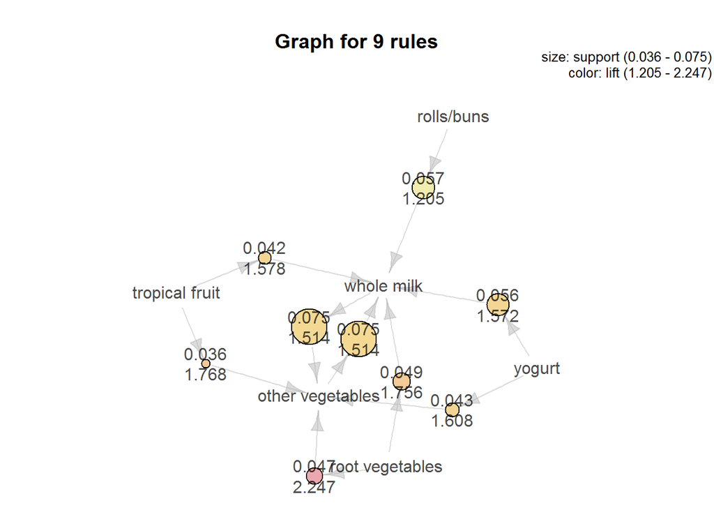